# Project1

Siyu Duan

9/19/2020

## Pre-survey

#### What is the people’ personal income in 2007 by gender?

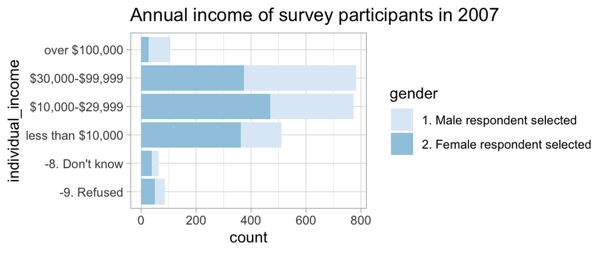

#### What is the employment status of people under the light of financial crisis? What do they think about their personal fince situation in 2009 under the light of financial crisis?

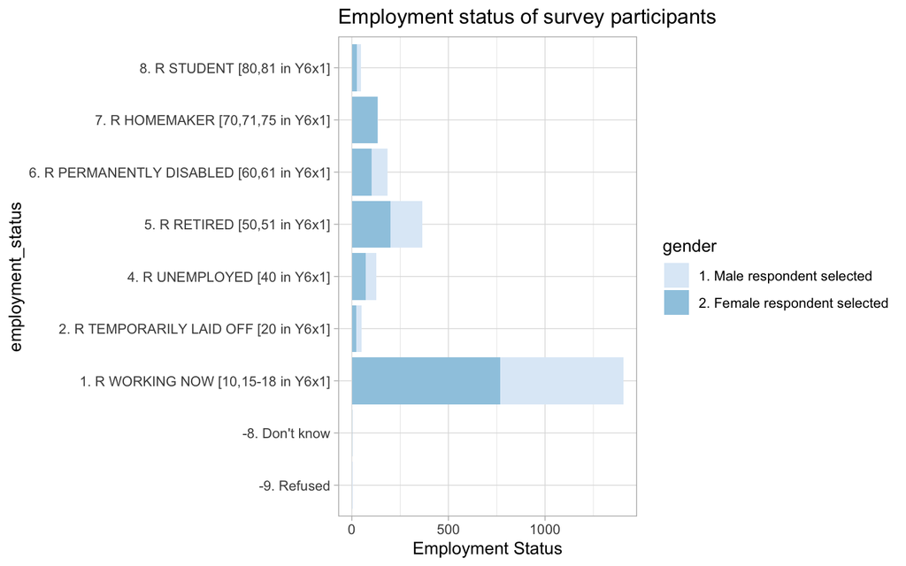

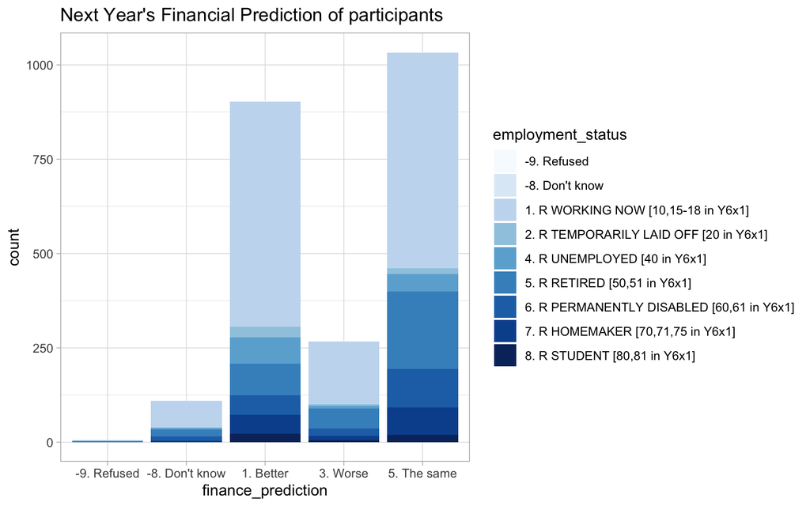

*In the employment status plot, it shows that most people were still working right now, and financial crisis may not impact them as much compared to people in other groups. Therefore, it actually make sense in the financial prediction plot that most people felt that thier financial situation would stay the same or even better. Surprisingly, I didn’t see many people were in the unemployment group and laid-off group under the circumtances of financial crisis. It might be due to the limitation of survey sampling method*